# Final Report - Did Covid change people’s perspective on what is important in a job

Kevin Pineda

4/10/2022

## Introduction

During the beginning of Covid, many white-collar working adults were forced to work away from the traditional office space that many were accustomed to. It was a drastic change that forced many families to conform to this new working way of life. Many people invested time and money into creating their own office space in their homes. Over two years have passed since the world was affected by the COVID-19 virus. People are now slowly returning to a new way of life. We are seeing more people return to an office setting or companies telling their employees to return. As computer science students, we must learn how these office settings are affecting the everyday individual. We will all mostly work in an office setting so understanding how our future peers view their working environment is important for all of our futures.

My question is *Did Covid change people’s perspective on what is important in a job?*. Workers are now comfortable, and invested, in their new work-from-home way of life. As someone who’s worked for both the private sector and government sector, I can distinguish what others may want in their jobs/careers. The way I will measure this is through a series of questions that all target a job/career importance to people. They will be *Working From Home*, *Work Environment*, *Work Location*, *Job Satisfaction*, and *Employee Benefits*. These target normal options people choose when looking for a job and will give me an idea as to what a small subset of the population thinks.

## Data

The way I went about obtaining the data is through the use of Google Surveys(https://surveys.google.com/). This service cost me roughly 0.10 cents a survey, and due to this cost, I limited my pool of surveys. The way Google Surveys obtains these surveys are through their AdMob Network which solicits users of apps to participate in surveys for “in-app rewards”. The sample population that I decided to use was the “entirety” of the continental United States, the “entirety” of the United Kingdom, and the western region of the United States. The salary was not a factor in the respondent’s decision. I believe compensation will change the person’s opinion of their job no matter what the option is. The respondents were asked the following question *“What is more important to you in a new job/career? (Regardless of salary)”*

An Example of the survey you would see is:

[figure not shown]

Survey Example

### Relevant Data

The data I have available is the age of the respondent, female/male gender option the respondent choose, region of the respondent, answer the respondent choose, and the response count for that specific combination of factors. I want to see the population as a whole, but having this information helps see if there was an unbalance in the survey respondents.

#### Goal

The goal is to see if something that came from Covid is a popular option (i.e. “Working from home”, “Work Location”). Even other factors can show us how this small subset of the population feels. Lets start with showing the break down of responses for each option.

```r
# Counting the total amount of responses for each option that was selected.

UK_JobSatCounter = 0
UK_WorkenvironmentCounter = 0
UK_WorkFrHomeCounter = 0
UK_WorkLocCounter = 0
UK_EmployeeBenCounter = 0

for(i in 1:dim(UK_Survey)[1]){

  if(UK_Survey$Q1.Answer[i] == "Job Satisfaction")
    UK_JobSatCounter = UK_JobSatCounter + UK_Survey$Response.Count[i]
  else if(UK_Survey$Q1.Answer[i] == "Work environment")
    UK_WorkenvironmentCounter = UK_WorkenvironmentCounter + UK_Survey$Response.Count[i]
  else if(UK_Survey$Q1.Answer[i] == "Working from home")
    UK_WorkFrHomeCounter = UK_WorkFrHomeCounter + UK_Survey$Response.Count[i]
  else if(UK_Survey$Q1.Answer[i] == "Work Location")
    UK_WorkLocCounter = UK_WorkLocCounter + UK_Survey$Response.Count[i]
  else if(UK_Survey$Q1.Answer[i] == "Employee Benefits")
    UK_EmployeeBenCounter = UK_EmployeeBenCounter + UK_Survey$Response.Count[i]
}

UKTotCount = UK_JobSatCounter+UK_WorkenvironmentCounter+UK_WorkFrHomeCounter+UK_WorkLocCounter+UK_EmployeeBenCounter


#--------------------------------------------------------------------------
USA_JobSatCounter = 0
USA_WorkenvironmentCounter = 0
USA_WorkFrHomeCounter = 0
USA_WorkLocCounter = 0
USA_EmployeeBenCounter = 0

for(i in 1:dim(USA_Survey)[1]){

  if(USA_Survey$Q1.Answer[i] == "Job Satisfaction")
    USA_JobSatCounter = USA_JobSatCounter + USA_Survey$Response.Count[i]
  else if(USA_Survey$Q1.Answer[i] == "Work environment")
    USA_WorkenvironmentCounter = USA_WorkenvironmentCounter + USA_Survey$Response.Count[i]
  else if(USA_Survey$Q1.Answer[i] == "Working from home")
    USA_WorkFrHomeCounter = USA_WorkFrHomeCounter + USA_Survey$Response.Count[i]
  else if(USA_Survey$Q1.Answer[i] == "Work Location")
    USA_WorkLocCounter = USA_WorkLocCounter + USA_Survey$Response.Count[i]
  else if(USA_Survey$Q1.Answer[i] == "Employee Benefits")
    USA_EmployeeBenCounter = USA_EmployeeBenCounter + USA_Survey$Response.Count[i]
}

TotCount = 0
USATotCount = USA_JobSatCounter+USA_WorkenvironmentCounter+USA_WorkFrHomeCounter+USA_WorkLocCounter+USA_EmployeeBenCounter

#--------------------------------------------------------------------------
USAWest_JobSatCounter = 0
USAWest_WorkenvironmentCounter = 0
USAWest_WorkFrHomeCounter = 0
USAWest_WorkLocCounter = 0
USAWest_EmployeeBenCounter = 0

for(i in 1:dim(USA_West_Survey)[1]){

  if(USA_West_Survey$Q1.Answer[i] == "Job Satisfaction")
    USAWest_JobSatCounter = USAWest_JobSatCounter + USA_West_Survey$Response.Count[i]
  else if(USA_West_Survey$Q1.Answer[i] == "Work environment")
    USAWest_WorkenvironmentCounter = USAWest_WorkenvironmentCounter + USA_West_Survey$Response.Count[i]
  else if(USA_West_Survey$Q1.Answer[i] == "Working from home")
    USAWest_WorkFrHomeCounter = USAWest_WorkFrHomeCounter + USA_West_Survey$Response.Count[i]
  else if(USA_West_Survey$Q1.Answer[i] == "Work Location")
    USAWest_WorkLocCounter = USAWest_WorkLocCounter + USA_West_Survey$Response.Count[i]
  else if(USA_West_Survey$Q1.Answer[i] == "Employee Benefits")
    USAWest_EmployeeBenCounter = USAWest_EmployeeBenCounter + USA_West_Survey$Response.Count[i]
}

#Testing
TotCount = 0
USAWestTotCount = USAWest_JobSatCounter+USAWest_WorkenvironmentCounter+USAWest_WorkFrHomeCounter+USAWest_WorkLocCounter+USAWest_EmployeeBenCounter
```

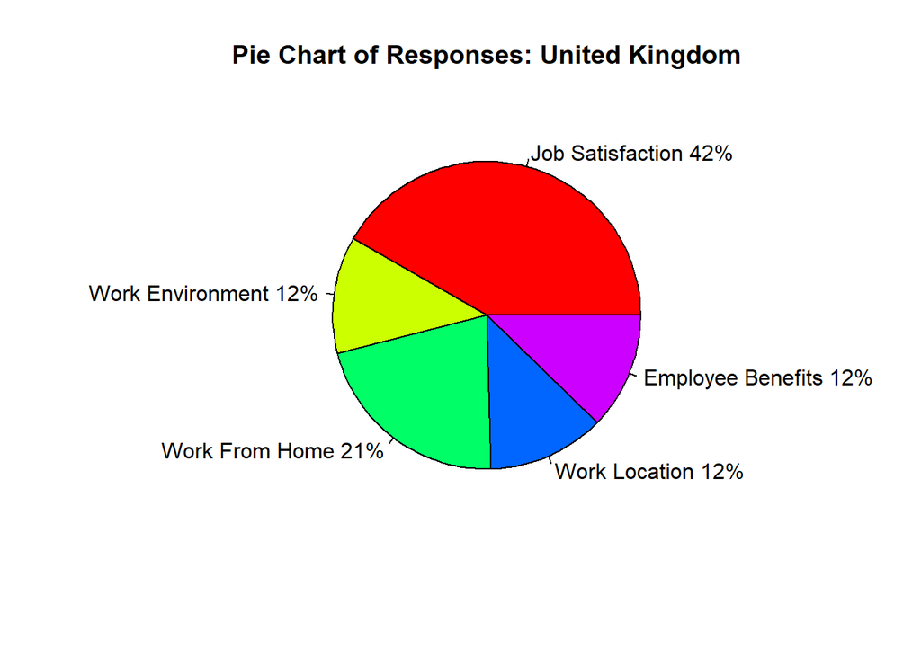

```
## [1] "Total Responses:  252"
```

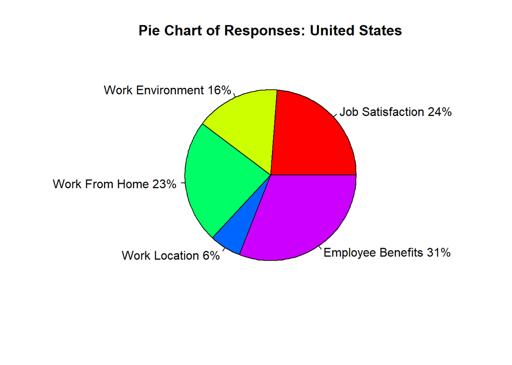

```
## [1] "Total Responses:  252"
```

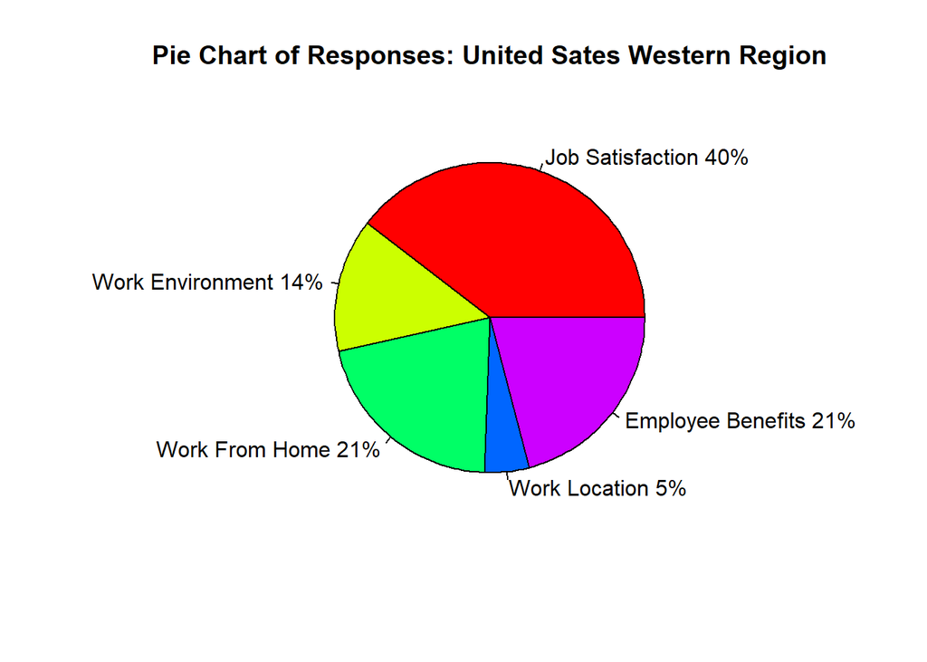

```
## [1] "Total Responses:  43"
```

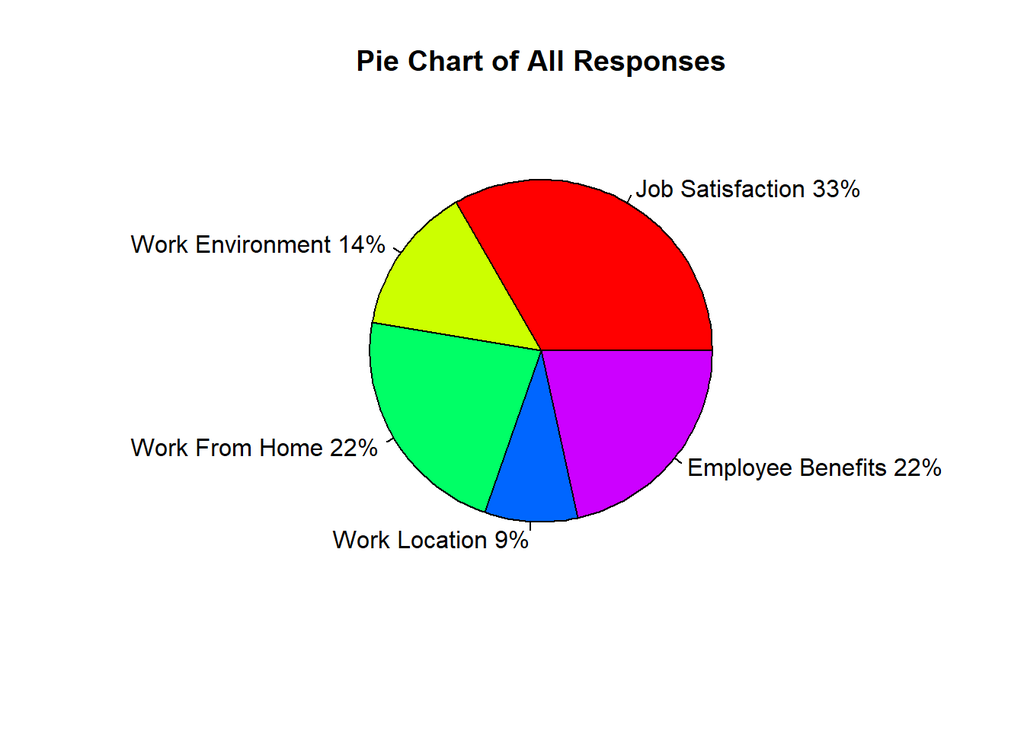

```
## [1] "Total Responses:  547"
```

## Analysis

Simply looking at the different responses, we can see similarities, but also some options were stronger than others. What factors we want to see are the options that correlate to social distancing are *Work From Home*. All other options are still factors that have changed the way workers view their careers. A report from CNBC explains how workers are leaning closer to working from home (https://www.cnbc.com/2022/03/16/how-people-have-changed-the-way-they-think-about-work-according-to-their-therapists.html), explains that “More people are choosing to work from home because they want to”. In a quick summary of the report, workers are looking to have a better work-life balance and have seen what they want in their careers.

#### Expectations

I expected more people to lean towards work from home than anything else. I also expected less people to choose work location considering the remote aspects of the jobs.

### Distributions

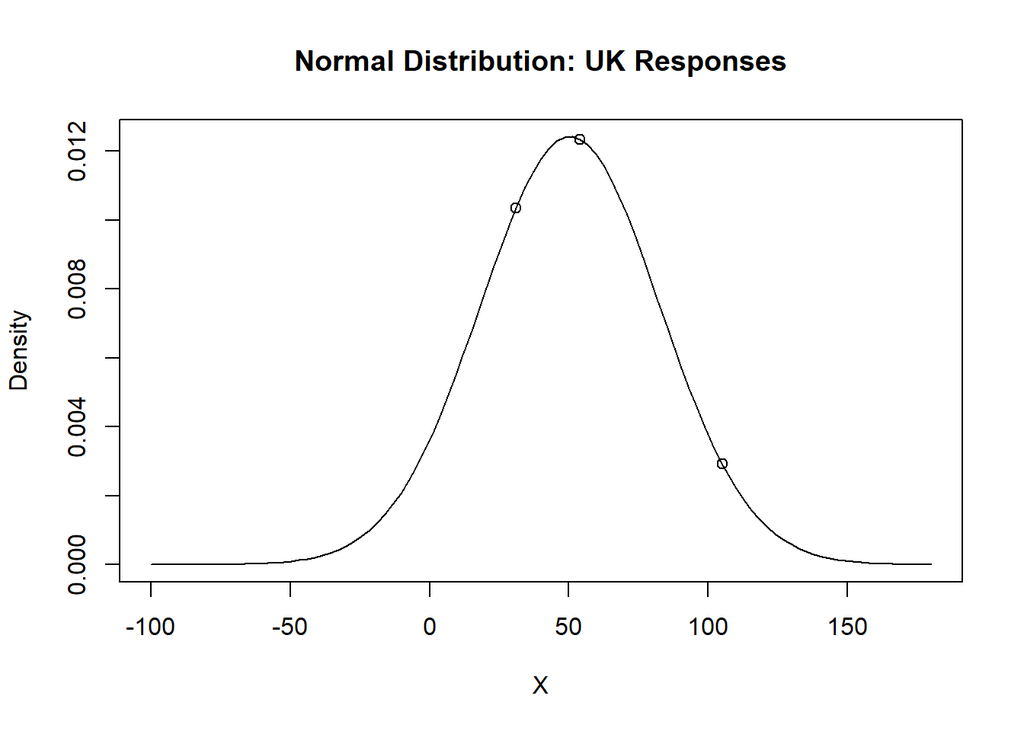

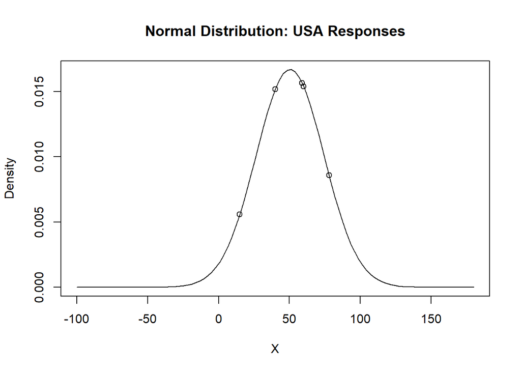

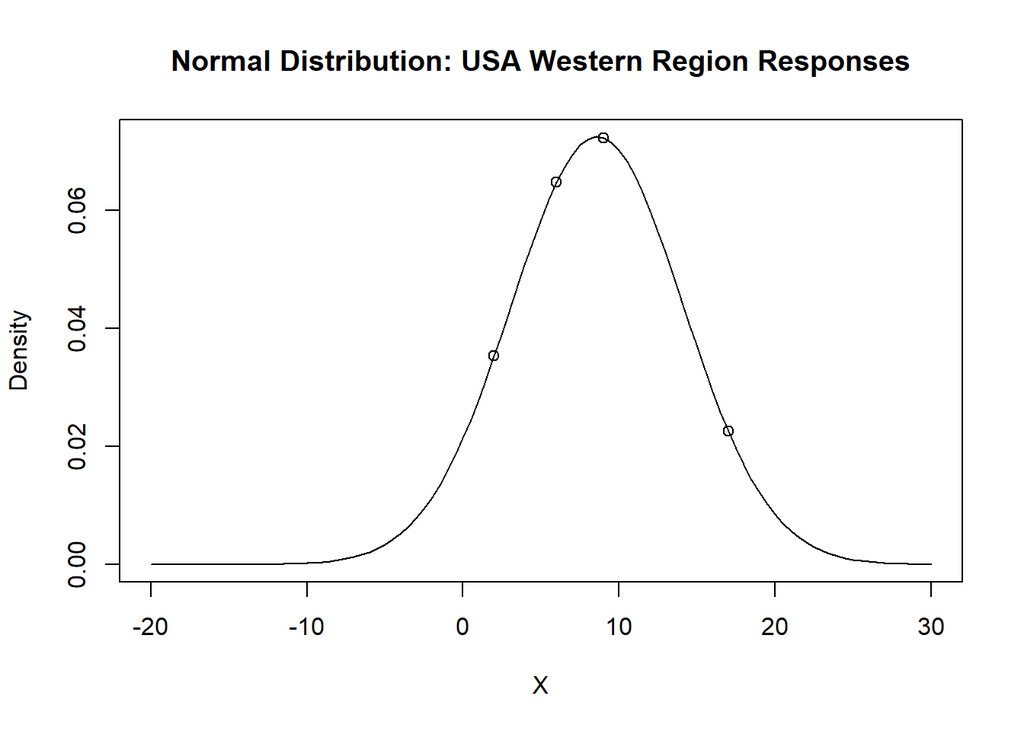

### Confidence Interval

How can we try and predict what the rest of the population might think is through a confidence interval. I will be using a binomial test in order to find this information. This can give us an idea of the percentage of the population, in the sample, that would choose a particular option. The most important options for me would be *Job Satisfaction*, *Work From Home*, and *Employee Benefits*.

#### Job Satisfaction

To start I will be looking at the probability of the population choosing the *Job Satisfaction* option.

```r
## UK
n = UKTotCount
x = UK_JobSatCounter
binom.test(x,n, conf.level = .95)
```

```
##
##  Exact binomial test
##
## data:  x and n
## number of successes = 105, number of trials = 252, p-value = 0.009663
## alternative hypothesis: true probability of success is not equal to 0.5
## 95 percent confidence interval:
##  0.3551146 0.4802027
## sample estimates:
## probability of success
##              0.4166667
```

```r
# US
n = USATotCount
x = USA_JobSatCounter
binom.test(x,n, conf.level = .95)
```

```
##
##  Exact binomial test
##
## data:  x and n
## number of successes = 60, number of trials = 252, p-value < 2.2e-16
## alternative hypothesis: true probability of success is not equal to 0.5
## 95 percent confidence interval:
##  0.1868855 0.2955790
## sample estimates:
## probability of success
##              0.2380952
```

```r
#Total Population
n = UKTotCount + USATotCount + USAWestTotCount
x = UK_JobSatCounter + USA_JobSatCounter + USAWest_JobSatCounter
binom.test(x,n, conf.level = .95)
```

```
##
##  Exact binomial test
##
## data:  x and n
## number of successes = 182, number of trials = 547, p-value = 3.987e-15
## alternative hypothesis: true probability of success is not equal to 0.5
## 95 percent confidence interval:
##  0.2933190 0.3739479
## sample estimates:
## probability of success
##              0.3327239
```

#### Work From Home

I will now be looking at the probability of the population choosing the *Work From Home* option.

```r
## UK
n = UKTotCount
x = UK_WorkFrHomeCounter
binom.test(x,n, conf.level = .95)
```

```
##
##  Exact binomial test
##
## data:  x and n
## number of successes = 54, number of trials = 252, p-value < 2.2e-16
## alternative hypothesis: true probability of success is not equal to 0.5
## 95 percent confidence interval:
##  0.1652709 0.2701566
## sample estimates:
## probability of success
##              0.2142857
```

```r
# US
n = USATotCount
x = USA_WorkFrHomeCounter
binom.test(x,n, conf.level = .95)
```

```
##
##  Exact binomial test
##
## data:  x and n
## number of successes = 59, number of trials = 252, p-value < 2.2e-16
## alternative hypothesis: true probability of success is not equal to 0.5
## 95 percent confidence interval:
##  0.1832667 0.2913580
## sample estimates:
## probability of success
##               0.234127
```

```r
#Total Population
n = UKTotCount + USATotCount + USAWestTotCount
x = UK_WorkFrHomeCounter + USA_WorkFrHomeCounter + USAWest_WorkFrHomeCounter
binom.test(x,n, conf.level = .95)
```

```
##
##  Exact binomial test
##
## data:  x and n
## number of successes = 122, number of trials = 547, p-value < 2.2e-16
## alternative hypothesis: true probability of success is not equal to 0.5
## 95 percent confidence interval:
##  0.1888108 0.2602820
## sample estimates:
## probability of success
##              0.2230347
```

#### Employee Benefits

Finally, I will now be looking at the probability of the population choosing the *Employee Benefits* option.

```r
## UK
n = UKTotCount
x = UK_EmployeeBenCounter
binom.test(x,n, conf.level = .95)
```

```
##
##  Exact binomial test
##
## data:  x and n
## number of successes = 31, number of trials = 252, p-value < 2.2e-16
## alternative hypothesis: true probability of success is not equal to 0.5
## 95 percent confidence interval:
##  0.08513483 0.17004761
## sample estimates:
## probability of success
##              0.1230159
```

```r
# US
n = USATotCount
x = USA_EmployeeBenCounter
binom.test(x,n, conf.level = .95)
```

```
##
##  Exact binomial test
##
## data:  x and n
## number of successes = 78, number of trials = 252, p-value = 1.386e-09
## alternative hypothesis: true probability of success is not equal to 0.5
## 95 percent confidence interval:
##  0.2530062 0.3705881
## sample estimates:
## probability of success
##              0.3095238
```

```r
#Total Population
n = UKTotCount + USATotCount + USAWestTotCount
x = UK_EmployeeBenCounter + USA_EmployeeBenCounter + USAWest_EmployeeBenCounter
binom.test(x,n, conf.level = .95)
```

```
##
##  Exact binomial test
##
## data:  x and n
## number of successes = 118, number of trials = 547, p-value < 2.2e-16
## alternative hypothesis: true probability of success is not equal to 0.5
## 95 percent confidence interval:
##  0.1819521 0.2525965
## sample estimates:
## probability of success
##              0.2157221
```

## Wrapping Up Conclusions

Using all the information and analysis, I can start to make a reasonable assumption for my sample population. The overall population seems to lean towards job satisfaction. The probability that Job Satisfaction is the choice, floats around 33% which is the highest out of all options chosen. Work From Home and Employee benefits were both close in the 2nd and 3d options. Work Location is significantly lower than all others simply looking at the total chart.

Answering the original question *Did Covid change people’s perspective on what is important in a job?*, and our “Covid variable” of *Work From Home*, it looks to be a popular option. It did come in second, but only beating *Employee Benefits* by a small margin. *Job Satisfaction* was the clear choice for my sample population. *Work Location* is also a variable I wanted to see what would happen and it came as I expected to be the lowest.

The population tells us that people are leaning towards having great job satisfaction. This term can be broad, but the typical description is having a satisfying job. How does this correlate to a pandemic changing workers’ perception? This does not answer our question directly. It could be many different things that can cause someone to choose that option.

Where we will pay attention to are the 2nd and 3rd options. We have a 22% probability of it being the options someone would say. The other options show a difference in decisions. Work Environment is oppositely related to Work From Home since a work environment would not be a direct thing for someone choosing work from home. Covid may have changed what people want in a job. Each location shows a different view on Work From Home, but it is still a very popular option worker would choose.

### Survey limitations

This survey has many issues, just as many others may have as well. This sample population is a very small subset of the general population. The limitations that the survey used to get respondents already divide the general population by a large amount. A larger sample population may have given us competently different results. This was limited due to funding (I.E. It was expensive). I myself lean towards a work from home culture since I really dislike commuting and being away from my family for long stretches of time.